# Covid

Sven Wellmann

17 June 2022

### Abstract

This article takes a deeper look into the Covid-19 pandemic.

# 1 Introduction

With the Covid-19 pandemic still threatening us 2 years on from its discovery, we now have more information and data to discover and establish some insights.

# 2 Data

This is the Data Collection for this question. Data is sourced from Hannah Ritchie & Roser (2020).

```r
covid_data <- DataCollect("data/Covid/")

covid <- covid_data[[3]]
```

# 3 Results

Plotting Africa vs other continents of total cases and total deaths due to Covid-19.

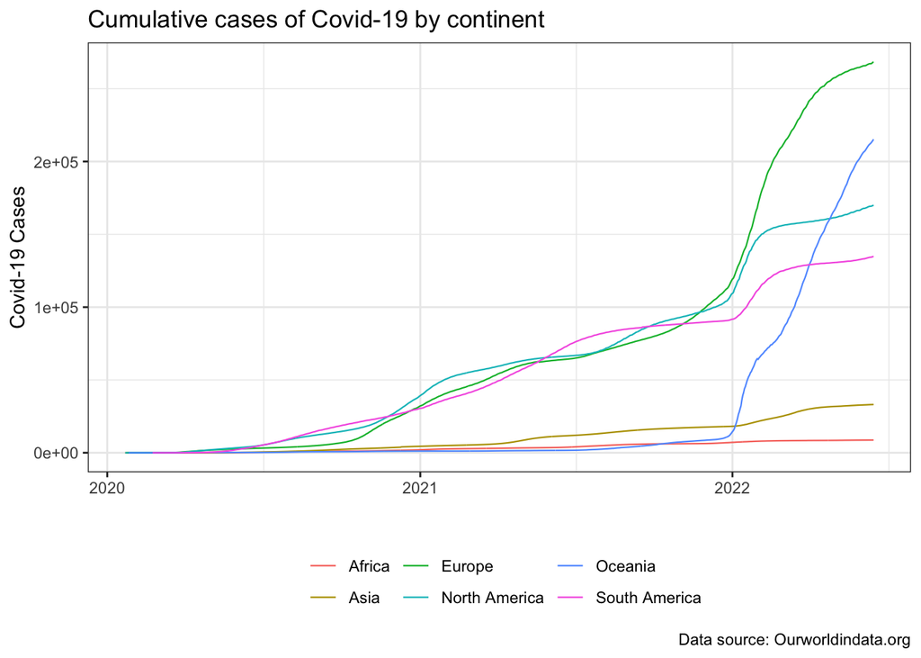

Figure 3.1: Cumulative Cases of Covid-19.

As one can see Africa does not have as many cases as other continents, this could be to a lack of infrastructure and testing it the remoteness of some areas that the virus has not yet reached.

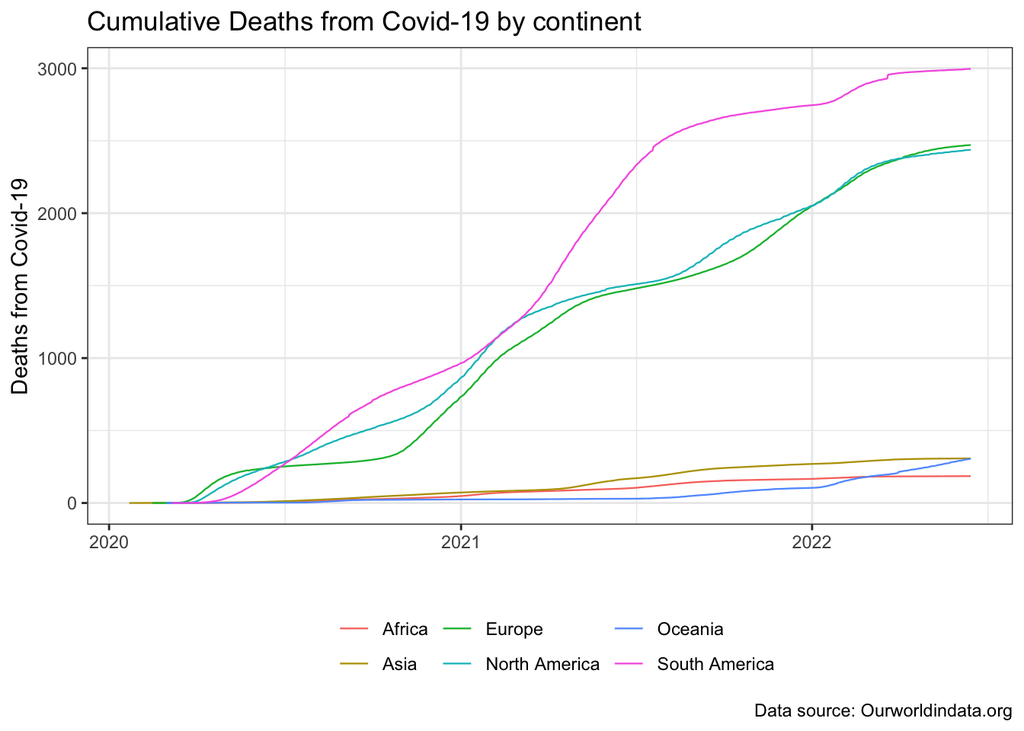

Figure 3.2: Cumulative Deaths from Covid-19.

Africa does have a high proportion of deaths in comparison to the amount of cases of Covid-19.

# 4 Seven day moving average

Seven day moving average of new cases and new deaths in order to see the relative size of the spikes for different continents

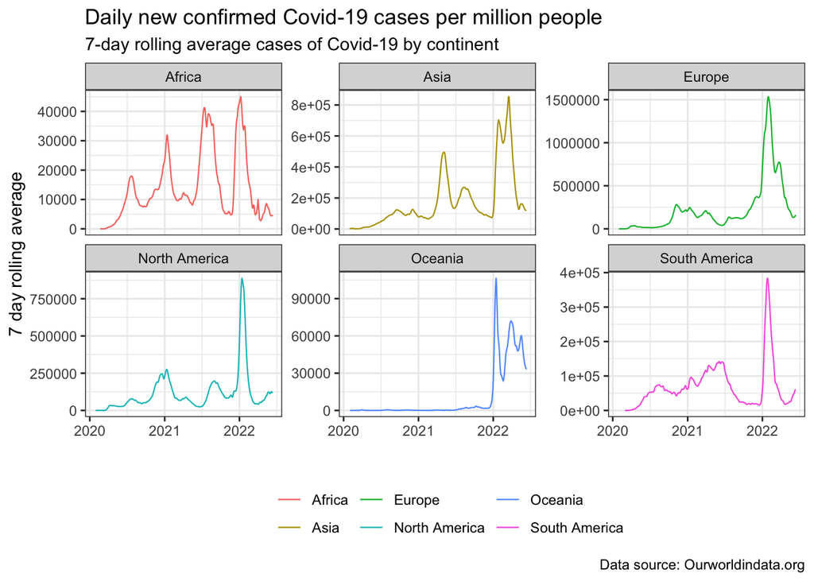

Figure 4.1: Seven day Moving Average of new Cases of Covid-19.

The spikes in Africa for both cases and deaths can be observed quite clearly.

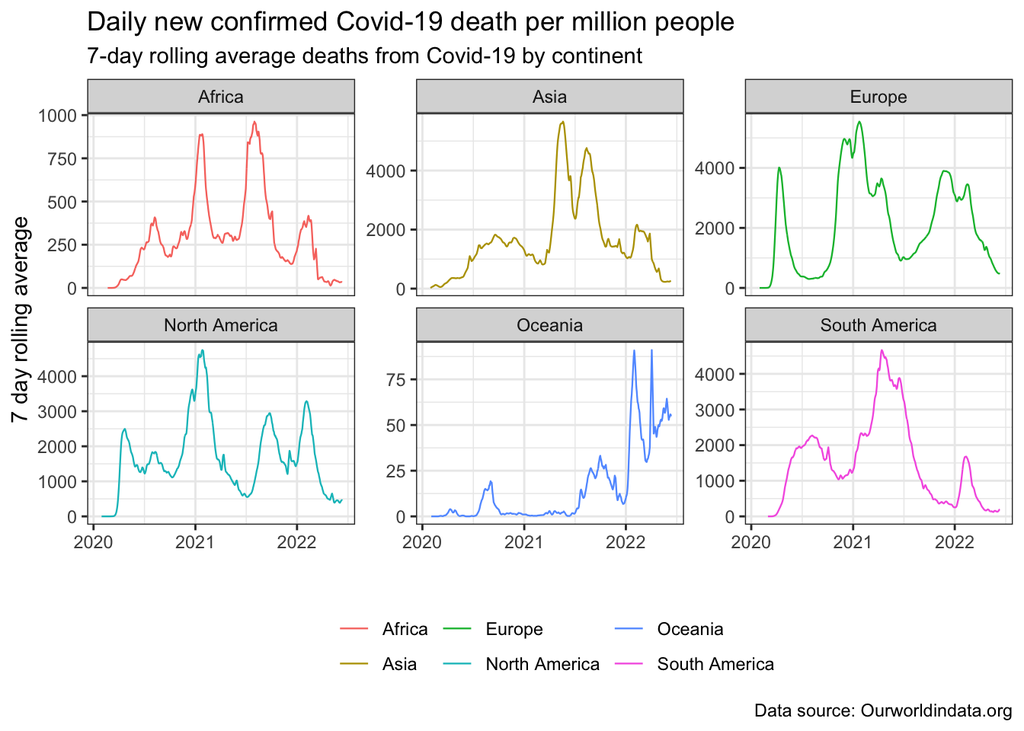

Figure 4.2: Seven day Moving Average of new Deaths from Covid-19.

Big difference plotting total cases and deaths vs total cases and deaths per million

# 5 Case Fatality Ratio

Looking at countries demographics to assess what affects the Caste Fatality Ratio of Covid-19.

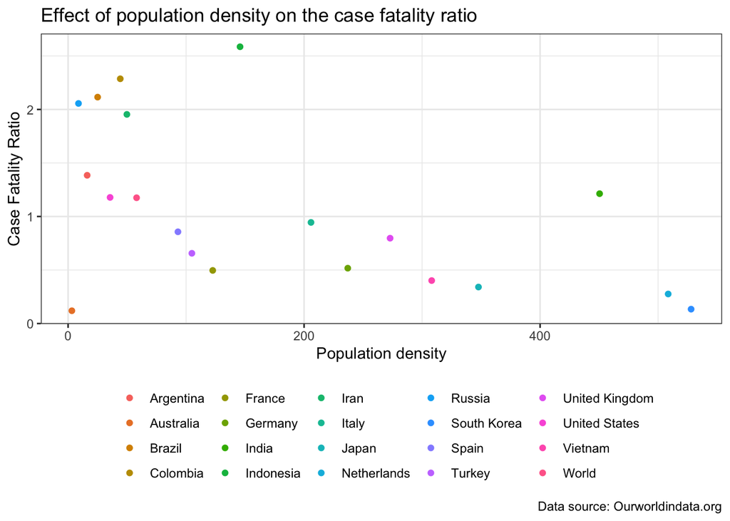

Figure 5.1: Effect of population density on the Case Fatality Ratio.

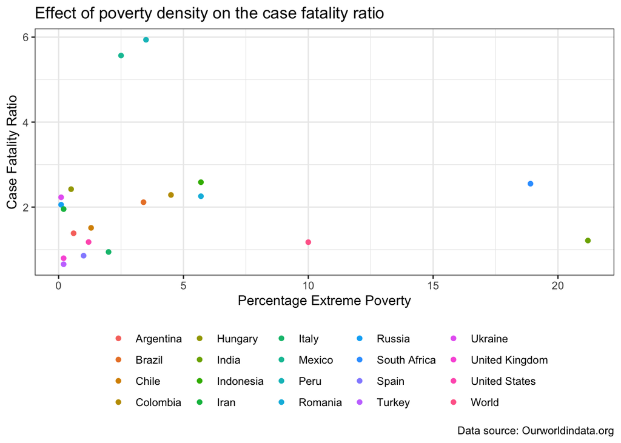

Figure 5.2: Effect of poverty density on the Case Fatality Ratio.

# 6 Hospital growth vs the Growth of Covid-19

This did not work as there was no change I could find in either the hospital beds or in the hand-washing facilities. Thus I could not find a proxy for hospital facility growth

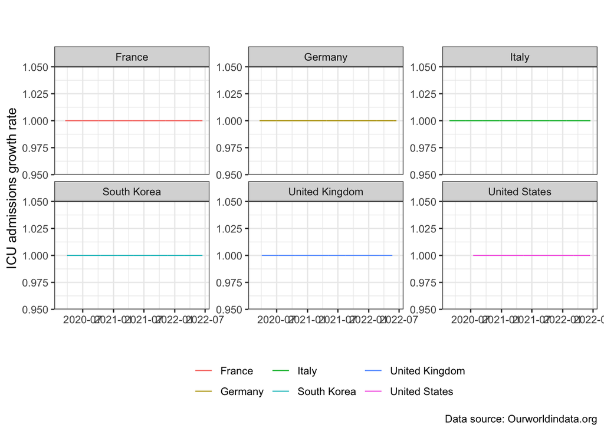

```r
countries_most_cases <- covid %>% group_by(location) %>%
    summarise(Cases = max(total_cases, na.rm=T)) %>%
    arrange(desc(Cases)) %>% pull(location)

countries_most_cases <- countries_most_cases[-c(1,2,3,4,5,6,7,8,10,21,24)]

# failed ICU bed one
covid %>% group_by(location) %>%
    filter(location %in% countries_most_cases[1:10]) %>%
    mutate(icugrowth = icu_patients/lag(icu_patients),
           bedgrowth = hospital_beds_per_thousand/lag(hospital_beds_per_thousand)) %>%
    select(date, location, icugrowth, bedgrowth) %>%
    drop_na() %>%
    ggplot() +
    geom_line(aes(x = date, y = bedgrowth, color = location), alpha = 1, size = 0.4) +
    theme_bw() +
    theme(legend.position = "bottom", legend.title=element_blank()) +
    labs(x = "",
         y = "ICU admissions growth rate",
         title = "",
         subtitle = "",
         caption = "Data source: Ourworldindata.org") +
    facet_wrap(~location, scales = "free_y")
```

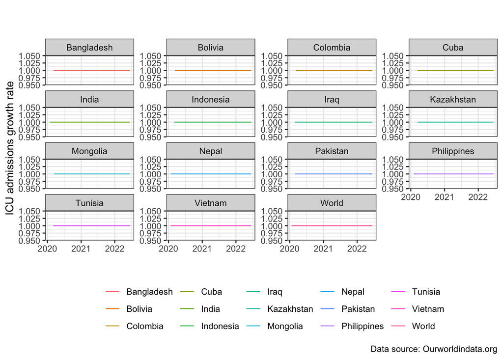

```r
countries_with_facilities <- covid %>% group_by(location) %>%
    mutate(max = max(total_cases)) %>%
    select(date, location, handwashing_facilities, max) %>%
    drop_na() %>% arrange(desc(max)) %>% pull(location) %>% unique()

#attempt handwashing facilities
covid %>% group_by(location) %>%
    filter(location %in% countries_with_facilities[1:15]) %>%
    mutate(icugrowth = icu_patients/lag(icu_patients),
           handwashinggrowth = handwashing_facilities/lag(handwashing_facilities)) %>%
    select(date, location, icugrowth, handwashinggrowth) %>%
    ggplot() +
    geom_line(aes(x = date, y = handwashinggrowth, color = location), alpha = 1, size = 0.4) +
    theme_bw() +
    theme(legend.position = "bottom", legend.title=element_blank()) +
    labs(x = "",
         y = "ICU admissions growth rate",
         title = "",
         subtitle = "",
         caption = "Data source: Ourworldindata.org") +
    facet_wrap(~location, scales = "free_y")
```

# References

Hannah Ritchie, L.R.-G., Edouard Mathieu & Roser, M. 2020. Coronavirus pandemic (COVID-19). *Our World in Data*.